# ETW2500 Semester 2 2024 Individual Assignment 1 31861148

Author

NgChenTing_31861148

# Stage 1: Loading Libraries and Reading CSV Files

## Load Libraries

```r
library(arules)
library(RColorBrewer)
library(tidyverse)
library(ggplot2)
library(plotly)
library(dplyr)
library(tidyr)
```

## Reading and Joining the CSV Files

```r
# Read the datasets
crewcast_ds <- read.csv("crewcast_clean.csv", header = TRUE)
moviemeta_ds <- read.csv("moviemetaclean.csv", header = TRUE)

# Join the csv files by id
Master_Dataset <- merge(crewcast_ds, moviemeta_ds, by = "id")
```

# Stage 2: Data Exploration

Display of all the values in Master Dataset.

```r
head(Master_Dataset)
```

```
  id           director        main_cast_1       main_cast_2       main_cast_3
1  1    'John Lasseter'        'Tom Hanks'       'Tim Allen'     'Don Rickles'
2  2  'Larry J. Franco'   'Robin Williams'   'Jonathan Hyde'   'Kirsten Dunst'
3  3    'Howard Deutch'   'Walter Matthau'     'Jack Lemmon'     'Ann-Margret'
4  4  'Forest Whitaker'  'Whitney Houston'  'Angela Bassett'  'Loretta Devine'
5  5   'Alan Silvestri'     'Steve Martin'    'Diane Keaton'    'Martin Short'
6  6     'Michael Mann'        'Al Pacino'  'Robert De Niro'      'Val Kilmer'
  adult   budget original_language                         productioncompany
1 FALSE 30000000                en                 'Pixar Animation Studios'
2 FALSE 65000000                en                        'TriStar Pictures'
3 FALSE        0                en                            'Warner Bros.'
4 FALSE 16000000                en  'Twentieth Century Fox Film Corporation'
5 FALSE        0                en                   'Sandollar Productions'
6 FALSE 60000000                en                     'Regency Enterprises'
            productioncountry release_date   revenue runtime vote_average
1  'United States of America'   10/30/1995 373554033      81          7.7
2  'United States of America'   12/15/1995 262797249     104          6.9
3  'United States of America'   12/22/1995         0     101          6.5
4  'United States of America'   12/22/1995  81452156     127          6.1
5  'United States of America'    2/10/1995  76578911     106          5.7
6  'United States of America'   12/15/1995 187436818     170          7.7
  vote_count      genre_1    genre_2    genre_3     genre_4 genre_5 genre_6
1       5415  'Animation'   'Comedy'   'Family'        <NA>    <NA>    <NA>
2       2413  'Adventure'  'Fantasy'   'Family'        <NA>    <NA>    <NA>
3         92    'Romance'   'Comedy'       <NA>        <NA>    <NA>    <NA>
4         34     'Comedy'    'Drama'  'Romance'        <NA>    <NA>    <NA>
5        173     'Comedy'       <NA>       <NA>        <NA>    <NA>    <NA>
6       1886     'Action'    'Crime'    'Drama'  'Thriller'    <NA>    <NA>
```

## Converting to Long Format

Given that the “Genre” data are distributed across multiple columns, we can consolidate them into a long format for better analysis and visualization.

```r
# Split and unnest Genres
Master_Dataset <- Master_Dataset %>%
  unite("Genres", genre_1:genre_6, sep = ",", na.rm = FALSE) %>%
  mutate(Genres = strsplit(Genres, ",")) %>%
  unnest(Genres)
```

## Unique Values

The applicable columns that will interest us are id, director, main casts, production company and genres.

```r
# Select applicable columns from Master Dataset
applicable_columns <- c("id", "director", "main_cast_1", "main_cast_2", "main_cast_3", "productioncompany", "Genres")
distinct_counts <- Master_Dataset[ , applicable_columns]

# Count unique values in each specified column, excluding NA
sapply(distinct_counts, function(col) {
  length(unique(na.omit(col)))
})
```

```
               id          director       main_cast_1       main_cast_2
            41270             18763             17622             21482
      main_cast_3 productioncompany            Genres
            23539             10138                33
```

The dataset consists of 41,270 unique movie IDs, 18,763 distinct directors, and 10,138 production companies. Additionally, the dataset also categorizes movies into 33 different genres.

## Identifying and Interpreting N/A or 0 values

```r
# Displays the number of 'NA' in each column
NA_counts <- sapply(Master_Dataset, function(x) sum(x == 'NA', na.rm = TRUE))
print(NA_counts)
```

```
               id          director       main_cast_1       main_cast_2
                0                 0                 0                 0
      main_cast_3             adult            budget original_language
                0                 0                 0                 0
productioncompany productioncountry      release_date           revenue
                0                 0                 0                 0
          runtime      vote_average        vote_count            Genres
                0                 0                 0            159933
```

When movies have fewer genres than the maximum number of columns allocated, the unused columns will be filled with NA which will be the case for genre_1 to genre_6. After converting to long format, these N/A values are replaced with ‘NA’ strings.

```r
# Displays the number of N/A values in each column
na_counts <- sapply(Master_Dataset, function(x) sum(is.na(x)))
print(na_counts)
```

```
               id          director       main_cast_1       main_cast_2
                0                 0              4740             11754
      main_cast_3             adult            budget original_language
            16650                 0                 0                 0
productioncompany productioncountry      release_date           revenue
            55800             26742                 0                36
          runtime      vote_average        vote_count            Genres
              948                36                36                 0
```

Similarly to Genre above, the same applied for main_cast_1, main_cast_2 and main_cast_3 as well. For older or lesser-known movies, information like the production company, production country, revenue, run time, vote average and vote count might not have been recorded at the time of data entry.

```r
# Displays number of 0 values in each column
zero_counts <- sapply(Master_Dataset, function(x) sum(x == 0, na.rm = TRUE))
print(zero_counts)
```

```
               id          director       main_cast_1       main_cast_2
                0                 0                12               276
      main_cast_3             adult            budget original_language
              342                 0            195696                 0
productioncompany productioncountry      release_date           revenue
                0                 0                 0            203880
          runtime      vote_average        vote_count            Genres
             6102             12828             12342                 0
```

Revenue, Run time and Budget can be justified by the same reason above as well, it suggest that the data wasn’t available or disclosed, rather than representing an actual value of 0. Whereas Vote count and Vote average of 0 might reflect that the movie has not received any votes. Moreover, 630 of the Main_Cast values are 0, this is a case of inconsistent data entry where if there is no main cast, it should be N/A instead.

## Potentially interesting variables

**[Aim 1] -** creating a recommendation system for consumers based on their genres of interest

**Columns that will interest consumers**: Director, Cast, Production Company, Genre, Vote_Count

The Director and Main Cast are important as consumers often have favorite directors and actors whose work they actively seek out. Additionally, the Production Company can impact consumer interest, especially if known for producing high-quality films which contributes in terms of brand recognition. High vote counts generally indicate a movie’s popularity and suggest a larger audience engagement which will assist in selecting quality movies for recommendations. Finally, Genre is a requirement, as it helps match movies to consumers’ specific genre preferences.

**[Aim 2]** - identifying focus areas for future directors

**Columns that will interest consumers**: budget, release_date, production company, vote_average and revenue

Similarly, Production company might play an important role in contributing to a film’s success and revenue. Moreover, understanding the relationship between budget and revenue can guide directors in making cost-effective decisions that still yield high returns. Release Date helps identify the time periods that attracts the most consumers. Finally, Vote Average and Revenue is a requirement as they are the main focus components in the aim.

## Modifications made

NA values can cause the algorithm to generate skewed or less meaningful association rules. Given the importance of “Main Cast”, “Genre” and “Vote Count” in Aim 1 and “Production Company”, “Budget”, “Vote Average”, “Revenue” in Aim 2 , it’s crucial to remove any rows with NA or 0 values in these columns to ensure the Apriori algorithm can function properly and generate meaningful associations.

NA values in columns like “Production Country” and “Run Time” can be ignored since they are not relevant to the analysis goals for Aim 1 and Aim 2. For “Main Casts” which are 0, they are treated as N/A and are to be removed later on in Aim 1 itself when converting to long format.

```r
# Replace 0 values in Main Cast with 0
Master_Dataset$main_cast_1[Master_Dataset$main_cast_1 == 0] <- NA
Master_Dataset$main_cast_2[Master_Dataset$main_cast_2 == 0] <- NA
Master_Dataset$main_cast_3[Master_Dataset$main_cast_3 == 0] <- NA

# Remove rows with NA or 0 values in specified columns
Master_Dataset <- Master_Dataset %>%
  filter(
    # Aim 1 variables
    Genres != 'NA',
    !is.na(vote_count) & vote_count != 0,
    # Aim 2 variables
    !is.na(productioncompany),
    budget != 0,
    !is.na(vote_average) & vote_average != 0,
    !is.na(revenue) & revenue != 0,
  )
```

Lastly, columns of character data types have single quotation marks in each value. We can clean the data to standardize the format.

```r
# Replace single quotation marks with empty strings
Master_Dataset$director <- gsub("'", "", Master_Dataset$director)
Master_Dataset$main_cast_1 <- gsub("'", "", Master_Dataset$main_cast_1)
Master_Dataset$main_cast_2 <- gsub("'", "", Master_Dataset$main_cast_2)
Master_Dataset$main_cast_3 <- gsub("'", "", Master_Dataset$main_cast_3)
Master_Dataset$productioncompany <- gsub("'", "", Master_Dataset$productioncompany)
Master_Dataset$productioncountry <- gsub("'", "", Master_Dataset$productioncountry)
Master_Dataset$Genres <- gsub("'", "", Master_Dataset$Genres)
```

# Stage 3: Data Preparation for Apriori for Assignment Aim 1

The steps for the conversion from dataset to transactional format includes identifying the transactional Items, converting interval values to percentiles, filter and create sets of transactional data.

## Step 1 - Identifying the transactional items

```r
Master_Dataset_Aim1 <- Master_Dataset[, c("id", "main_cast_1" , "main_cast_2" , "main_cast_3" ,"Genres", "vote_count")]
```

To create an effective recommendation system for consumers, Main Cast is selected as a key dimension as it aligns with audience preferences and helps in recommending films featuring actors known for their consistent performance and genre choices which improves the overall consumer experience. In addition, Vote Count is also selected as a variable to recommend movies of good quality to consumers.

## Step 2 - Converting interval values to percentile

```r
# Function to categorize columns into Low, Medium and High
categorize_LMH <- function(column) {

  # Calculate percentiles
  percentiles <- quantile(column, probs = c(0.33, 0.67))

  cut(column,
      breaks = c(-Inf, percentiles, Inf),
      labels = c("Low", "Medium", "High"),
      right = TRUE)
}

# Categorize Vote average into Low and High
Master_Dataset_Aim1$vote_count <- as.numeric(Master_Dataset_Aim1$vote_count)
Master_Dataset_Aim1$vote_count <- categorize_LMH(Master_Dataset_Aim1$vote_count)
```

Vote Count is categorized into three distinct categories: Low, Medium & High using 33rd and 67th percentiles. It accommodates different consumer interests, as some may prefer well-received films with high ratings, while others may explore films with polarizing appeal in lower-rated categories. For recommending content, focusing on high and medium vote counts ensures that we highlight movies with large audiences and quality, while filtering out those with lower ratings. Thereby improving the likelihood of attracting more viewers and ensuring the most promising recommendations.

## Step 3 - Filter and create sets of transactional data

The main focus of genres are Fantasy, Drama and Action. Therefore, 3 sets of transactional data will be created.

```r
# Filtering of rows to include those of interest
fantasy_all <- filter(Master_Dataset_Aim1, Genres == " Fantasy")
drama_all <- filter(Master_Dataset_Aim1, Genres == " Drama")
action_all <- filter(Master_Dataset_Aim1, Genres == " Action")

# Since we only want to recommend shows that reach a big or medium audience
fantasy_all <- filter(fantasy_all, vote_count != "Low")
drama_all <- filter(drama_all, vote_count != "Low")
action_all <- filter(action_all, vote_count != "Low")

# Remove the columns of interest
fantasy_all <- fantasy_all[, !(names(fantasy_all) %in% c("Genres", "vote_count"))]
drama_all <- drama_all[, !(names(drama_all) %in% c("Genres","vote_count"))]
action_all <- action_all[, !(names(action_all) %in% c("Genres", "vote_count"))]

# A summary of the 3 datasets
print("Fantasy Summary")
```

```
[1] "Fantasy Summary"
```

```r
summary(fantasy_all)
```

```
       id        main_cast_1        main_cast_2        main_cast_3
 Min.   :    2   Length:392         Length:392         Length:392
 1st Qu.: 2880   Class :character   Class :character   Class :character
 Median :11010   Mode  :character   Mode  :character   Mode  :character
 Mean   :11942
 3rd Qu.:17008
 Max.   :42847
```

```r
print("Drama  Summary")
```

```
[1] "Drama  Summary"
```

```r
summary(drama_all)
```

```
       id        main_cast_1        main_cast_2        main_cast_3
 Min.   :    6   Length:1449        Length:1449        Length:1449
 1st Qu.: 3311   Class :character   Class :character   Class :character
 Median :11332   Mode  :character   Mode  :character   Mode  :character
 Mean   :13133
 3rd Qu.:19456
 Max.   :43692
```

```r
print("Action Summary")
```

```
[1] "Action Summary"
```

```r
summary(action_all)
```

```
       id        main_cast_1        main_cast_2        main_cast_3
 Min.   :    6   Length:969         Length:969         Length:969
 1st Qu.: 3619   Class :character   Class :character   Class :character
 Median :11068   Mode  :character   Mode  :character   Mode  :character
 Mean   :12706
 3rd Qu.:18447
 Max.   :43645
```

The dataset is first filtered to isolate rows belonging to the genres of Fantasy, Drama, and Action, respectively. Next, we remove rows with a “Low” vote count to only recommend movies that have reached a large or medium audience. After filtering, we remove the columns for Genres and Vote Count from each dataset, as they are no longer necessary for the Apriori Analysis results. This leaves only Main Cast that will contribute to recommending content from these specific genres.

```r
# Convert Columns to Factors
transaction_fantasy <- fantasy_all %>%  mutate(across(everything(), as.factor))
transaction_drama <- drama_all %>%  mutate(across(everything(), as.factor))
transaction_action <- action_all %>%  mutate(across(everything(), as.factor))

# Convert to Transactions
transaction_fantasy <- as(transaction_fantasy,"transactions")
transaction_drama <- as(transaction_drama,"transactions")
transaction_action <- as(transaction_action,"transactions")
```

The 3 sets of data sets are converted into Factor data type and transaction format.

1. Creating the transactional data for Fantasy.

```r
# Convert to long format for Main Cast
fantasy_all$id <- 1:nrow(fantasy_all)
fantasy_long <- gather(fantasy_all, key = "main_cast_number", value = "Main_Cast", -id, na.rm = TRUE)
fantasy_long <- fantasy_long[, c("id", "Main_Cast")]
fantasy_long <- fantasy_long[order(fantasy_long$id), ]

# Split and view them by movie id
fantasy_list <- split(fantasy_long$Main_Cast, fantasy_long$id)
fantasy_transaction <- as(fantasy_list, "transactions")
inspect(head(fantasy_transaction, 10))
```

```
     items                  transactionID
[1]  { Jonathan Hyde,
       Kirsten Dunst,
       Robin Williams}                 1
[2]  { Dominique Pinon,
       Judith Vittet,
       Ron Perlman}                    2
[3]  { Brad Pitt,
       Bruce Willis,
       Madeleine Stowe}                3
[4]  { Chris Tucker,
       Keith David,
       Larenz Tate}                    4
[5]  { Meg Ryan,
       Robert Downey Jr.,
       Sam Neill}                      5
[6]  { Bill Paxton,
       Kevin Bacon,
       Tom Hanks}                      6
[7]  { Frances McDormand,
       Patricia Arquette,
       U Aung Ko}                      7
[8]  { Afemo Omilami,
       Ted Manson}                     8
[9]  { Eileen Colgan,
       Jeni Courtney,
       Mick Lally}                     9
[10] { Mary-Louise Parker,
       Susan Sarandon,
       Tommy Lee Jones}                10
```

This reshapes the fantasy_all dataset, which contains fantasy movies and their respective main cast members, into a long format where each movie has its cast members listed individually. It then groups the cast members by id to ensure each transaction represents a unique set of actors for each film. Finally, the list of actors for each movie is converted into a transactional dataset, where each transaction is an individual movie with its main cast. This allows for association rule analysis on the patterns of actors within fantasy films.

The same applies for Drama and Action below.

2. Creating the transactional data for Drama.

```r
# Convert to long format for Main Cast
drama_all$id <- 1:nrow(drama_all)
drama_long <- gather(drama_all, key = "main_cast_number", value = "Main_Cast", -id, na.rm = TRUE)
drama_long <- drama_long[, c("id", "Main_Cast")]
drama_long <- drama_long[order(drama_long$id), ]

# Split and view them by movie id
drama_list <- split(drama_long$Main_Cast, drama_long$id)
drama_transaction <- as(drama_list, "transactions")
inspect(head(drama_transaction, 10))
```

```
     items                   transactionID
[1]  { Al Pacino,
       Robert De Niro,
       Val Kilmer}                      1
[2]  { Annette Bening,
       Michael Douglas,
       Michael J. Fox}                  2
[3]  { Joe Pesci,
       Robert De Niro,
       Sharon Stone}                    3
[4]  { Emma Thompson,
       Hugh Grant,
       Kate Winslet}                    4
[5]  { Elisabeth Shue,
       Julian Sands,
       Nicolas Cage}                    5
[6]  { Brad Pitt,
       Bruce Willis,
       Madeleine Stowe}                 6
[7]  { Christine Cavanaugh,
       Danny Mann,
       Miriam Margolyes}                7
[8]  { Meg Ryan,
       Robert Downey Jr.,
       Sam Neill}                       8
[9]  { Anne Bancroft,
       Ellen Burstyn,
       Winona Ryder}                    9
[10] { David Ogden Stiers,
       Irene Bedard,
       Mel Gibson}                      10
```

3. Creating the transactional data for Action.

```r
# Convert to long format for Main Cast
action_all$id <- 1:nrow(action_all)
action_long <- gather(action_all, key = "main_cast_number", value = "Main_Cast", -id, na.rm = TRUE)
action_long <- action_long[, c("id", "Main_Cast")]
action_long <- action_long[order(action_long$id), ]

# Split and view them by movie id
action_list <- split(action_long$Main_Cast, action_long$id)
action_transaction <- as(action_list, "transactions")
inspect(head(action_transaction, 10))
```

```
     items                     transactionID
[1]  { Al Pacino,
       Robert De Niro,
       Val Kilmer}                        1
[2]  { Dorian Harewood,
       Jean-Claude Van Damme,
       Powers Boothe}                     2
[3]  { Izabella Scorupco,
       Pierce Brosnan,
       Sean Bean}                         3
[4]  { Jennifer Lopez,
       Wesley Snipes,
       Woody Harrelson}                   4
[5]  { Antonio Banderas,
       Julianne Moore,
       Sylvester Stallone}                5
[6]  { Chris Tucker,
       Keith David,
       Larenz Tate}                       6
[7]  { Alain Chabat,
       Josiane Balasko,
       Victoria Abril}                    7
[8]  { Jason Patric,
       Larry Drake,
       Thandie Newton}                    8
[9]  { Maria Schrader,
       Michael von Au,
       Pierre Sanoussi-Bliss}             9
[10] { Azzedine Alaïa,
       Christy Turlington,
       Giorgio Armani}                    10
```

Moreover, to analyse the relationship between genres, a separate transaction data is also created.

```r
# Extract only id and Genres
only_genres <- Master_Dataset[, c("id","Genres")]

# Split and group by id
data_list <- lapply(split(only_genres$Genres, only_genres$id), function(x) unique(unlist(strsplit(x, ", "))))
data_transaction <- as(data_list, "transactions")

# Example of genre transactions
inspect(head(data_transaction,10))
```

```
     items                                transactionID
[1]  { Animation,  Comedy,  Family}       1
[2]  { Adventure,  Family,  Fantasy}      2
[3]  { Comedy,  Drama,  Romance}          4
[4]  { Action,  Crime,  Drama,  Thriller} 6
[5]  { Action,  Adventure,  Thriller}     9
[6]  { Action,  Adventure,  Thriller}     10
[7]  { Comedy,  Drama,  Romance}          11
[8]  { Drama,  History}                   14
[9]  { Action,  Adventure}                15
[10] { Crime,  Drama}                     16
```

This splits the genres by id and ensures that only unique genres are included for each movie. This transformation eliminates duplicate genres and structures the data so that each movie is associated with a list of distinct genres. The resulting list is converted into a transactional format, where each transaction represents a movie, and the items in the transaction are its genres.

# Stage 4: Genre Analysis Assignment Aim 1

Over the course of their careers, actors often become reliable markers for film quality and specific genres, especially if they have consistently chosen similar roles. As highlighted by Liu et al. (2014), evidence shows that “consistent” stars are more successful in attracting viewers. This consistency creates strong audience expectations and trust in certain actors’ work. Therefore, after consideration, for Aim 1, the only variable of focus is the Main Cast.

## Fantasy

```r
# Apriori Algorithm
arules_fantasy_all <- apriori(fantasy_transaction,
                               parameter = c(supp = 0.01,
                                             conf = 0.01)
                               )
```

```
Apriori

Parameter specification:
 confidence minval smax arem  aval originalSupport maxtime support minlen
       0.01    0.1    1 none FALSE            TRUE       5    0.01      1
 maxlen target  ext
     10  rules TRUE

Algorithmic control:
 filter tree heap memopt load sort verbose
    0.1 TRUE TRUE  FALSE TRUE    2    TRUE

Absolute minimum support count: 3

set item appearances ...[0 item(s)] done [0.00s].
set transactions ...[1055 item(s), 391 transaction(s)] done [0.00s].
sorting and recoding items ... [3 item(s)] done [0.00s].
creating transaction tree ... done [0.00s].
checking subsets of size 1 done [0.00s].
writing ... [3 rule(s)] done [0.00s].
creating S4 object  ... done [0.00s].
```

```r
inspect(sort(arules_fantasy_all, by = "support", decreasing = TRUE))
```

```
    lhs    rhs             support    confidence coverage lift count
[1] {}  => { Gene Hackman} 0.01534527 0.01534527 1        1    6
[2] {}  => { Bruce Willis} 0.01278772 0.01278772 1        1    5
[3] {}  => { Kurt Russell} 0.01023018 0.01023018 1        1    4
```

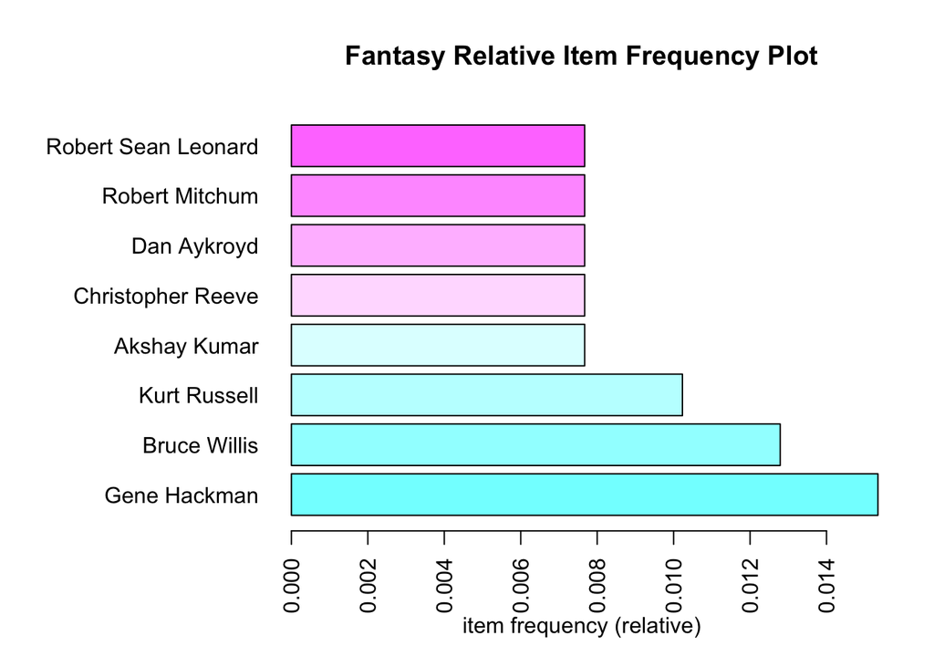

```r
itemFrequencyPlot(fantasy_transaction,
                  topN = 8,
                  col = cm.colors(8),
                  main = 'Fantasy Relative Item Frequency Plot',
                  type = "relative",
                  horiz = TRUE
                  )
```

Aside from them, it can also be observed from the Relative Item Frequency Plot that Akshay Kumar, Christopher Reeve, Dan Aykroyd, Robert Mitchum and Robert Sean Leonard works would interest consumers looking for movies in the Fantasy genre as well. Their works are worth considering for consumer who are looking to dive deeper into fantasy cinema.

## Drama

```r
arules_drama_all <- apriori(drama_transaction,
                               parameter = c(supp = 0.004,
                                             conf = 0.001)
                               )
```

```
Apriori

Parameter specification:
 confidence minval smax arem  aval originalSupport maxtime support minlen
      0.001    0.1    1 none FALSE            TRUE       5   0.004      1
 maxlen target  ext
     10  rules TRUE

Algorithmic control:
 filter tree heap memopt load sort verbose
    0.1 TRUE TRUE  FALSE TRUE    2    TRUE

Absolute minimum support count: 5

set item appearances ...[0 item(s)] done [0.00s].
set transactions ...[3309 item(s), 1445 transaction(s)] done [0.00s].
sorting and recoding items ... [7 item(s)] done [0.00s].
creating transaction tree ... done [0.00s].
checking subsets of size 1 2 done [0.00s].
writing ... [7 rule(s)] done [0.00s].
creating S4 object  ... done [0.00s].
```

```r
inspect(sort(arules_drama_all, by = "support", decreasing = TRUE))
```

```
    lhs    rhs                  support     confidence  coverage lift count
[1] {}  => { Robert De Niro}    0.006920415 0.006920415 1        1    10
[2] {}  => { Keanu Reeves}      0.004844291 0.004844291 1        1     7
[3] {}  => { Woody Harrelson}   0.004152249 0.004152249 1        1     6
[4] {}  => { Catherine Deneuve} 0.004152249 0.004152249 1        1     6
[5] {}  => { Jackie Chan}       0.004152249 0.004152249 1        1     6
[6] {}  => { Glenn Close}       0.004152249 0.004152249 1        1     6
[7] {}  => { Tom Cruise}        0.004152249 0.004152249 1        1     6
```

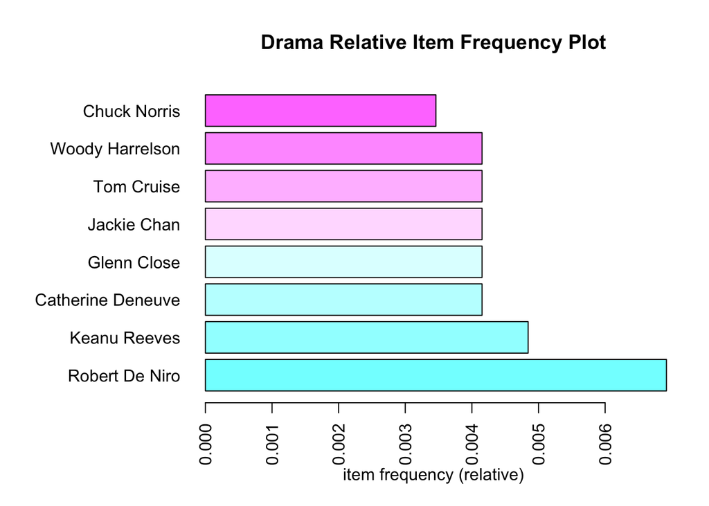

```r
itemFrequencyPlot(drama_transaction,
                  topN = 8,
                  col = cm.colors(8),
                  main = 'Drama Relative Item Frequency Plot',
                  type = "relative",
                  horiz = TRUE)
```

Additionally, if the consumer is interested in exploring more options within the Drama genre, Catherine Deneuve, Glenn Close, Jackie Chan, Tom Cruise, and Woody Harrelson are excellent choices as well. The item frequency plot shows that these actors frequently appear in dramatic films which makes them valuable recommendations for anyone looking for powerful and emotional storytelling.

## Action

```r
arules_action_all <- apriori(action_transaction,
                               parameter = c(supp = 0.005,
                                             conf = 0.005)
                               )
```

```
Apriori

Parameter specification:
 confidence minval smax arem  aval originalSupport maxtime support minlen
      0.005    0.1    1 none FALSE            TRUE       5   0.005      1
 maxlen target  ext
     10  rules TRUE

Algorithmic control:
 filter tree heap memopt load sort verbose
    0.1 TRUE TRUE  FALSE TRUE    2    TRUE

Absolute minimum support count: 4

set item appearances ...[0 item(s)] done [0.00s].
set transactions ...[2321 item(s), 966 transaction(s)] done [0.00s].
sorting and recoding items ... [8 item(s)] done [0.00s].
creating transaction tree ... done [0.00s].
checking subsets of size 1 2 done [0.00s].
writing ... [8 rule(s)] done [0.00s].
creating S4 object  ... done [0.00s].
```

```r
inspect(sort(arules_action_all, by = "support", decreasing = TRUE))
```

```
    lhs    rhs                   support     confidence  coverage lift count
[1] {}  => { Catherine Deneuve}  0.006211180 0.006211180 1        1    6
[2] {}  => { Gene Hackman}       0.006211180 0.006211180 1        1    6
[3] {}  => { Robert De Niro}     0.005175983 0.005175983 1        1    5
[4] {}  => { Charlie Sheen}      0.005175983 0.005175983 1        1    5
[5] {}  => { Gregory Peck}       0.005175983 0.005175983 1        1    5
[6] {}  => { Sylvester Stallone} 0.005175983 0.005175983 1        1    5
[7] {}  => { Tommy Lee Jones}    0.005175983 0.005175983 1        1    5
[8] {}  => { Kirk Douglas}       0.005175983 0.005175983 1        1    5
```

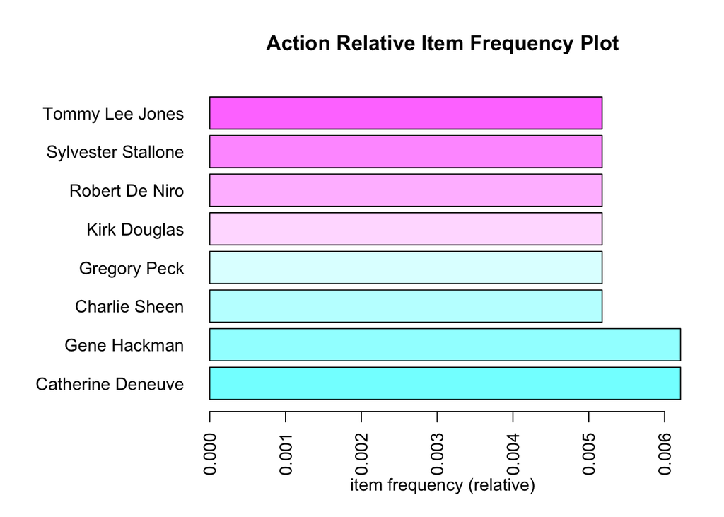

```r
itemFrequencyPlot(action_transaction,
                  topN = 8,
                  col = cm.colors(8),
                  main = 'Action Relative Item Frequency Plot',
                  type = "relative",
                  horiz = TRUE)
```

## Solely on Genre

Aside from main casts, it’s also helpful to analyze the genres that are frequently associated with the consumer’s genres of interest. This approach provides a deeper understanding of genre patterns and identify additional genres to recommend to those interested in a particular genre.

```r
# Apriori Algorithm
arules_genres_all <- apriori(data_transaction,
                               parameter = c(supp = 0.1,
                                             conf = 0.4,
                                             minlen = 2)
                               )
```

```
Apriori

Parameter specification:
 confidence minval smax arem  aval originalSupport maxtime support minlen
        0.4    0.1    1 none FALSE            TRUE       5     0.1      2
 maxlen target  ext
     10  rules TRUE

Algorithmic control:
 filter tree heap memopt load sort verbose
    0.1 TRUE TRUE  FALSE TRUE    2    TRUE

Absolute minimum support count: 514

set item appearances ...[0 item(s)] done [0.00s].
set transactions ...[20 item(s), 5146 transaction(s)] done [0.00s].
sorting and recoding items ... [9 item(s)] done [0.00s].
creating transaction tree ... done [0.00s].
checking subsets of size 1 2 done [0.00s].
writing ... [5 rule(s)] done [0.00s].
creating S4 object  ... done [0.00s].
```

```r
# Filter rules to include mentions of Action, Drama, and Fantasy
rules_filtered <- subset(arules_genres_all,
                         rhs %in% c(" Action", " Drama"))

# Display filtered rules
inspect(sort(rules_filtered, by = "support", decreasing = TRUE))
```

```
    lhs             rhs       support   confidence coverage  lift      count
[1] { Romance}   => { Drama}  0.1268947 0.6773859  0.1873300 1.4129825 653
[2] { Thriller}  => { Action} 0.1251457 0.4404925  0.2841042 1.6692005 644
[3] { Thriller}  => { Drama}  0.1230082 0.4329685  0.2841042 0.9031439 633
[4] { Adventure} => { Action} 0.1039642 0.5715812  0.1818888 2.1659476 535
```

For Drama, the strongest association is with Romance, with a support of 0.1269. The confidence indicates that 67.74% of Romance films are also classified as Drama, reflecting a strong overlap between emotional storytelling and dramatic elements. Additionally, Thriller also has a noticeable connection to both Drama, showing that many Thriller films contain dramatic themes.

In terms of Action, with a support of 0.1040 and confidence values, 57.16% of Adventure films also fall under the Action genre. This shows that audiences often enjoy the combination of adventurous and action-packed story lines. The Thriller genre is also closely tied to Action, with a support of 0.1251 and confidence meaning 44.05% of Thriller films feature Action sequences.

If the consumer is interested in Drama genre movies, Romance and Thriller might interest them as well. If the consumer if interested in Action genres, they should look into movies in the Adventure genres.

```r
# Apriori Algorithm
arules_genres_all <- apriori(data_transaction,
                               parameter = c(supp = 0.03,
                                             conf = 0.1,
                                             minlen = 2)
                               )
```

```
Apriori

Parameter specification:
 confidence minval smax arem  aval originalSupport maxtime support minlen
        0.1    0.1    1 none FALSE            TRUE       5    0.03      2
 maxlen target  ext
     10  rules TRUE

Algorithmic control:
 filter tree heap memopt load sort verbose
    0.1 TRUE TRUE  FALSE TRUE    2    TRUE

Absolute minimum support count: 154

set item appearances ...[0 item(s)] done [0.00s].
set transactions ...[20 item(s), 5146 transaction(s)] done [0.00s].
sorting and recoding items ... [16 item(s)] done [0.00s].
creating transaction tree ... done [0.00s].
checking subsets of size 1 2 3 done [0.00s].
writing ... [75 rule(s)] done [0.00s].
creating S4 object  ... done [0.00s].
```

```r
# Filter rules to include mentions of  Fantasy
rules_filtered <- subset(arules_genres_all,
                         rhs %in% " Fantasy")

# Display filtered rules
inspect(sort(rules_filtered, by = "support", decreasing = TRUE))
```

```
    lhs             rhs        support    confidence coverage   lift     count
[1] { Adventure} => { Fantasy} 0.04488923 0.2467949  0.18188885 2.555345 231
[2] { Family}    => { Fantasy} 0.03420132 0.3444227  0.09930043 3.566196 176
[3] { Action}    => { Fantasy} 0.03167509 0.1200295  0.26389429 1.242800 163
```

With a support of 0.0342, Rule 2 indicates that 34.44% of Family films are also classified as Fantasy. This suggests a strong connection between Family and Fantasy films, making them a popular choice for consumers seeking magical and imaginative stories suitable for all ages. Consumers interested in Fantasy should also consider exploring the Adventure genre, as 24.68% of Adventure movies also belong to the Fantasy category. For viewers who enjoy more action-packed experiences, Action-Fantasy films are a frequent recommendation.

## Comparative Analysis

Main cast recommendations:

- **Fantasy**: Gene Hackman, Bruce Willis, Kurt Russell
- **Drama**: Robert De Niro, Keanu Reeves
- **Action**: Catherine Deneuve, Gene Hackman

When comparing the main cast recommendations across Fantasy, Drama, and Action, we see distinct trends that align with consumer interests and demand in each genre. For Fantasy, actors like Gene Hackman, Bruce Willis, and Kurt Russell bring an adventurous and imaginative presence. In Drama, Robert De Niro and Keanu Reeves are highlighted, who are known for their character-driven performances, appealing to audiences seeking depth and intensity. Meanwhile, in Action, Catherine Deneuve and Gene Hackman are recognized for their roles in adrenaline-filled movies. Notably, Gene Hackman appears in both Fantasy and Action, showcasing his versatility and fame in transitioning between fantastical and action-packed storylines.

Commonly associated genre recommendations:

- **Fantasy**: Family, Adventure
- **Drama**: Romance, Thriller
- **Action**: Adventure, Thriller

For consumers interested in **Fantasy**, the most recommended genres are **Family** and **Adventure**, reflecting a demand for imaginative stories that cater to both adventurous and family-friendly entertainment. In contrast, **Drama** is strongly linked to **Romance** and **Thriller**, showing a consumer demand for emotionally intense films that explore deep relationships or suspenseful plots. **Action**, on the other hand, is frequently associated with **Adventure** and **Thriller**, highlighting the demand for fast-paced films that deliver both excitement and suspense.

The key difference between these recommendations lies in the consumer focus: Fantasy leans toward exploration, while Drama and Action emphasize emotional complexity or high-energy sequences to meet different viewer preferences.

# Stage 5: Data Preparation for Apriori for Assignment Aim 2

## Step 1 - Identifying the transactional items

The columns that will provide beneficial insights to directors are budget, release date, production company, vote average and revenue. Additionally, release dates are converted into their respective months to identify which months are commonly associated with the variables in the analysis.

```r
# Only selected specific variables needed for Aim 2
Master_Dataset_Aim2 <- Master_Dataset[, c("budget", "release_date","productioncompany", "vote_average","revenue")]

Master_Dataset_Aim2 <- Master_Dataset_Aim2 %>%
  mutate(release_date = mdy(release_date),   # Convert to Date object
         release_month = month(release_date, label = TRUE))   # Extract month name

head(Master_Dataset_Aim2, 5)
```

```
# A tibble: 5 × 6
  budget   release_date productioncompany     vote_average revenue release_month
  <chr>    <date>       <chr>                        <dbl>   <dbl> <ord>
1 30000000 1995-10-30   " Pixar Animation St…          7.7  3.74e8 Oct
2 30000000 1995-10-30   " Pixar Animation St…          7.7  3.74e8 Oct
3 30000000 1995-10-30   " Pixar Animation St…          7.7  3.74e8 Oct
4 65000000 1995-12-15   " TriStar Pictures"            6.9  2.63e8 Dec
5 65000000 1995-12-15   " TriStar Pictures"            6.9  2.63e8 Dec
```

## Step 2 - Converting interval values to percentile

Revenue tends to have a more straightforward distribution, where the difference between low and high revenue is significant. By focusing on just two categories, the analysis can be simplified, which is particularly important since revenue is the target variable of interest analyzed in the Apriori algorithm. This approach allows for clearer insights into how other factors like production company are associated with either high or low revenue, without the potential noise that might come from a middle category that could blur these relationships. The same reasoning can be applied to budget as well.

For Vote Count, it can be referred to in Step 2 of Stage 3.

Since Vote Average operates on a smaller scale, categorizing it allows us to focus on selecting and analyzing the qualities of only the best-rated films. By narrowing down to the highest-rated movies, directors can gain deeper insights into what truly resonates with audiences at the top tier. This categorization can help directors tailor future projects to align more closely with audience preferences, enabling them to make better decisions.

```r
# Function to categorize columns into Low, Medium and High
categorize_LMH <- function(column) {

  # Calculate percentiles
  percentiles <- quantile(column, probs = c(0.33, 0.67))

  cut(column,
      breaks = c(-Inf, percentiles, Inf),
      labels = c("Low", "Medium", "High"),
      right = TRUE)
}

# Function to categorize columns into Low and High
categorize_LH <- function(column) {

  # Calculate the 50th percentile
  median_value <- quantile(column, probs = 0.5)

  cut(column,
      breaks = c(-Inf, median_value, Inf),
      labels = c("Low", "High"),
      right = TRUE)
}

# Categorize Vote Average to Low, Medium and High
Master_Dataset_Aim2$vote_average <- as.numeric(Master_Dataset_Aim2$vote_average)
Master_Dataset_Aim2$vote_average <- categorize_LMH(Master_Dataset_Aim2$vote_average)

# Categorize Revenue to Low and High
Master_Dataset_Aim2$revenue <- as.numeric(Master_Dataset_Aim2$revenue)
Master_Dataset_Aim2$revenue <- categorize_LH(Master_Dataset_Aim2$revenue)

# Categorize Budget to Low and High
Master_Dataset_Aim2$budget <- as.numeric(Master_Dataset_Aim2$budget)
Master_Dataset_Aim2$budget <- categorize_LH(Master_Dataset_Aim2$budget)
```

## Step 3 - Filter and create sets of transactional data

To create the recommendation system for directors with vote average and revenue as the target interests, two sets of transactional data will be created namely high vote averages and high revenue. This insight can help directors replicate successful outcomes and gain advice on what’s best to attract audience’s liking or to maximize revenue.

```r
# Filtering of rows to include those of interest
vote_avg_high_all <- filter(Master_Dataset_Aim2, vote_average == "High")
revenue_high_all <- filter(Master_Dataset_Aim2, revenue == "High")

# Remove the columns of interest
vote_avg_high_all <- vote_avg_high_all[, !(names(vote_avg_high_all) %in% c("vote_average", "revenue"))]
revenue_high_all <- revenue_high_all[, !(names(revenue_high_all) %in% c("vote_average", "revenue"))]
```

```r
# Convert Columns to Factors
transaction_vote_avg_high <- vote_avg_high_all %>%  mutate(across(everything(), as.factor))
transaction_revenue_high <- revenue_high_all %>%  mutate(across(everything(), as.factor))

# Convert to Transactions
transaction_vote_avg_high <- as(transaction_vote_avg_high,"transactions")
transaction_revenue_high <- as(transaction_revenue_high,"transactions")
```

# Stage 6: Genre Analysis Assignment Aim 2

## Vote Average

```r
arules_vote_avg_high <- apriori(transaction_vote_avg_high,
                               parameter = c(supp = 0.1,
                                             conf = 0.1))
```

```
Apriori

Parameter specification:
 confidence minval smax arem  aval originalSupport maxtime support minlen
        0.1    0.1    1 none FALSE            TRUE       5     0.1      1
 maxlen target  ext
     10  rules TRUE

Algorithmic control:
 filter tree heap memopt load sort verbose
    0.1 TRUE TRUE  FALSE TRUE    2    TRUE

Absolute minimum support count: 408

set item appearances ...[0 item(s)] done [0.00s].
set transactions ...[2077 item(s), 4081 transaction(s)] done [0.00s].
sorting and recoding items ... [4 item(s)] done [0.00s].
creating transaction tree ... done [0.00s].
checking subsets of size 1 2 done [0.00s].
writing ... [4 rule(s)] done [0.00s].
creating S4 object  ... done [0.00s].
```

```r
inspect(sort(arules_vote_avg_high, by = "support", decreasing = TRUE))
```

```
    lhs    rhs                 support   confidence coverage lift count
[1] {}  => {budget=Low}        0.6172507 0.6172507  1        1    2519
[2] {}  => {budget=High}       0.3827493 0.3827493  1        1    1562
[3] {}  => {release_month=Dec} 0.1443274 0.1443274  1        1     589
[4] {}  => {release_month=Sep} 0.1188434 0.1188434  1        1     485
```

According to Rule 1, films with lower production costs are still capable of achieving high audience approval, indicating that a large budget is not always necessary for critical success. In other words, if the director’s goal is to achieve high audience approval, a smaller budget can still produce well-received films.

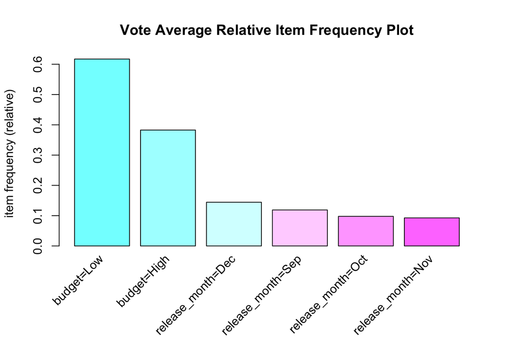

```r
itemFrequencyPlot(transaction_vote_avg_high,
                  topN = 6,
                  col = cm.colors(6),
                  main = "Vote Average Relative Item Frequency Plot",
                  type = "relative")
```

The relative item frequency plot shows that movies with the highest vote averages are typically released towards the end of the year, particularly in December and September.

## Revenue

```r
arules_revenue_high <- apriori(transaction_revenue_high,
                               parameter = c(supp = 0.1,
                                             conf = 0.1))
```

```
Apriori

Parameter specification:
 confidence minval smax arem  aval originalSupport maxtime support minlen
        0.1    0.1    1 none FALSE            TRUE       5     0.1      1
 maxlen target  ext
     10  rules TRUE

Algorithmic control:
 filter tree heap memopt load sort verbose
    0.1 TRUE TRUE  FALSE TRUE    2    TRUE

Absolute minimum support count: 673

set item appearances ...[0 item(s)] done [0.00s].
set transactions ...[2489 item(s), 6736 transaction(s)] done [0.00s].
sorting and recoding items ... [5 item(s)] done [0.00s].
creating transaction tree ... done [0.00s].
checking subsets of size 1 2 done [0.00s].
writing ... [5 rule(s)] done [0.00s].
creating S4 object  ... done [0.00s].
```

```r
inspect(sort(arules_revenue_high, by = "support", decreasing = TRUE))
```

```
    lhs    rhs                 support   confidence coverage lift count
[1] {}  => {budget=High}       0.7476247 0.7476247  1        1    5036
[2] {}  => {budget=Low}        0.2523753 0.2523753  1        1    1700
[3] {}  => {release_month=Dec} 0.1239608 0.1239608  1        1     835
[4] {}  => {release_month=Jun} 0.1123812 0.1123812  1        1     757
[5] {}  => {release_month=Jul} 0.1030285 0.1030285  1        1     694
```

For directors aiming to maximize revenue, in contrast to the Apriori results for vote average, the data indicates that high revenue films are more commonly associated with higher budgets as seen in the strong support for Rule 1. Additionally, high-revenue films are often released in December, June, and July, suggesting these months could be strategic for maximizing box office returns. By aligning their budgets and release dates with these trends, directors can enhance their chances of achieving greater financial returns.

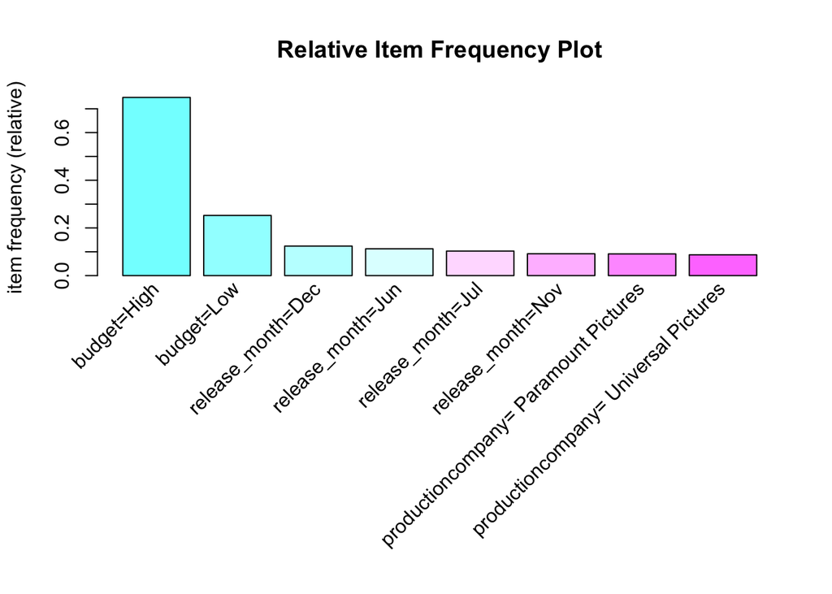

```r
itemFrequencyPlot(transaction_revenue_high,
                  topN = 8,              # Number of top items to display
                  col = cm.colors(8),      # Color palette for the bars
                  main = "Relative Item Frequency Plot",  # Title of the plot
                  type = "relative")      # Relative frequency
```

From the relative item frequency plot, there are also two production companies mentioned which are Paramount Pictures and Universal Pictures, for generating significant revenue. Directors might consider collaborating with these companies to maximize revenue potential for their projects.

# Stage 7: Conclusion

For consumers interested in Fantasy, consider exploring movies featuring Gene Hackman or Bruce Willis, and also delve into the Family and Adventure genres. Consumers interested in Drama genres, can look into movies starring Robert De Niro or Keanu Reeves and also consider Romance and Thriller genres. For fans of Action, look for movies with Catherine Deneuve or Gene Hackman, and consider the Adventure and Thriller genres.

Directors aiming to optimize their film’s performance should consider releasing their projects towards the end of the year, particularly in December and September, as these months are linked to higher vote averages. For directors aiming to maximize revenue, focusing on high-budget productions and timing releases in December, June, or July can be more effective. Additionally, collaborating with successful production companies identified for their revenue generation like Paramount Pictures and Universal Pictures could further enhance revenue.

# References

Liu, A., Liu, Y., and Mazumdar, T., 2014. Star power in the eye of the beholder: a study of the inﬂuenceof stars in the movie industry. Marketing letters, 25 (4), 385–396.